# Data.Table Package

BH Analytics, LLC

# The Data.Table Package

- A different approach to dataframes in R
- data.table replaces the data.frame
- A data.table object is also a data.frame
  - You can use a data.table anywhere you can use a data.frame
- Goals of the data.table package
- Reduce time to write code through sensical syntax (opinion)
- Reduce the time code takes to run through efficient copying ordered grouping and ordered joins (fact)
- The computing time gains all depend on sorting (setting keys) the data.table then leveraging the sort order for joins, group by calculations, and subsetting

# Creating a data.table

- We can directly create a data.table similar to a data.frame
- We can easily convert a data.frame to a data.table
- We can use `fread()` to read in structured text as a data.table, this replaces`read.csv()`

```r
library(data.table)

## We can directly create a data.table just like a dataframe
dt1 <-
  data.table(x1=1:10,
             x2=10:1)
dt1
```

```
##     x1 x2
##  1:  1 10
##  2:  2  9
##  3:  3  8
##  4:  4  7
##  5:  5  6
##  6:  6  5
##  7:  7  4
##  8:  8  3
##  9:  9  2
## 10: 10  1
```

```r
str(dt1)
```

```
## Classes 'data.table' and 'data.frame':   10 obs. of  2 variables:
##  $ x1: int  1 2 3 4 5 6 7 8 9 10
##  $ x2: int  10 9 8 7 6 5 4 3 2 1
##  - attr(*, ".internal.selfref")=<externalptr>
```

```r
is.data.frame(dt1)
```

```
## [1] TRUE
```

```r
is.data.table(dt1)
```

```
## [1] TRUE
```

# Creating a data.table 2

- We can easily convert a data.frame to a data.table
- We can use `fread` to read in structured text as a data.table (this replaces `read.csv`)
- `fread` is fast! (stands for fast file read)

```r
library(data.table)
library(plyr) # for the baseball data

## We can convert existing dataframe to dt
data(baseball)
str(baseball)
```

```
## 'data.frame':    21699 obs. of  22 variables:
##  $ id   : chr  "ansonca01" "forceda01" "mathebo01" "startjo01" ...
##  $ year : int  1871 1871 1871 1871 1871 1871 1871 1872 1872 1872 ...
##  $ stint: int  1 1 1 1 1 1 1 1 1 1 ...
##  $ team : chr  "RC1" "WS3" "FW1" "NY2" ...
##  $ lg   : chr  "" "" "" "" ...
##  $ g    : int  25 32 19 33 29 29 29 46 37 25 ...
##  $ ab   : int  120 162 89 161 128 146 145 217 174 130 ...
##  $ r    : int  29 45 15 35 35 40 36 60 26 40 ...
##  $ h    : int  39 45 24 58 45 47 37 90 46 53 ...
##  $ X2b  : int  11 9 3 5 3 6 5 10 3 11 ...
##  $ X3b  : int  3 4 1 1 7 5 7 7 0 0 ...
##  $ hr   : int  0 0 0 1 3 1 2 0 0 0 ...
##  $ rbi  : int  16 29 10 34 23 21 23 50 15 16 ...
##  $ sb   : int  6 8 2 4 3 2 2 6 0 2 ...
##  $ cs   : int  2 0 1 2 1 2 2 6 1 2 ...
##  $ bb   : int  2 4 2 3 1 4 9 16 1 1 ...
##  $ so   : int  1 0 0 0 0 1 1 3 1 0 ...
##  $ ibb  : int  NA NA NA NA NA NA NA NA NA NA ...
##  $ hbp  : int  NA NA NA NA NA NA NA NA NA NA ...
##  $ sh   : int  NA NA NA NA NA NA NA NA NA NA ...
##  $ sf   : int  NA NA NA NA NA NA NA NA NA NA ...
##  $ gidp : int  NA NA NA NA NA NA NA NA NA NA ...
```

```r
baseball_dt <-
  data.table(baseball)
## Fast File Read
cohort <- fread("Data/patient_demo.csv")
```

# data.table Commands

- Recall a data.table is also a data.frame so all the data.frame methods work
- Data.table prints only the first 5 and last 5 rows of a table if the table is larger than 100 rows

```r
## list all data.tables and their size
tables()
```

```
##           NAME    NROW NCOL MB                                        COLS KEY
## 1: baseball_dt  21,699   22  2                 id,year,stint,team,lg,g,...
## 2:      cohort 100,000    6  3 patient_id,hosp_id,age,gender,mortality,SES
## 3:         dt1      10    2  0                                       x1,x2
## Total: 5MB
```

```r
## Confirm this is a data.table (and a data frame)
class(cohort)
```

```
## [1] "data.table" "data.frame"
```

```r
## the usual methods for data.frames all work for
summary(cohort)
```

```
##    patient_id        hosp_id            age            gender           mortality             SES
##  Min.   :100000   Min.   :  1.00   Min.   : 22.00   Length:100000      Length:100000      Length:100000
##  1st Qu.:125000   1st Qu.: 25.00   1st Qu.: 58.00   Class :character   Class :character   Class :character
##  Median :150000   Median : 51.00   Median : 65.00   Mode  :character   Mode  :character   Mode  :character
##  Mean   :150000   Mean   : 50.55   Mean   : 64.93
##  3rd Qu.:174999   3rd Qu.: 75.00   3rd Qu.: 72.00
##  Max.   :199999   Max.   :100.00   Max.   :109.00
```

```r
## Data.tables print the first and last 5 rows
cohort
```

```
##         patient_id hosp_id age gender mortality  SES
##      1:     100000      77  70   Male       Yes  Med
##      2:     100001      45  64   Male        No  Low
##      3:     100002       5  76   Male        No  Med
##      4:     100003      13  51   Male        No High
##      5:     100004      70  76   Male        No  Low
##     ---
##  99996:     199995      60  66   Male        No  Med
##  99997:     199996      14  71   Male        No  Low
##  99998:     199997      39  73   Male       Yes  Med
##  99999:     199998      21  60 Female        No High
## 100000:     199999      81  61   Male        No  Low
```

# The i= Argument

- We will use the square brackets to interact with data.tables (the subset operator)
- Forget everything you know about the square brackets (sorry!), it is different in data.table
- The first argument to the square brackets is `i=`, which we use to subset the rows of the data.table
- This can be an integer vector or a Boolean vector
- Any references to variables will be first resolved within the data.table environment

```r
cohort[] # prints all
```

```
##         patient_id hosp_id age gender mortality  SES
##      1:     100000      77  70   Male       Yes  Med
##      2:     100001      45  64   Male        No  Low
##      3:     100002       5  76   Male        No  Med
##      4:     100003      13  51   Male        No High
##      5:     100004      70  76   Male        No  Low
##     ---
##  99996:     199995      60  66   Male        No  Med
##  99997:     199996      14  71   Male        No  Low
##  99998:     199997      39  73   Male       Yes  Med
##  99999:     199998      21  60 Female        No High
## 100000:     199999      81  61   Male        No  Low
```

```r
## the first row
cohort[i=1]
```

```
##    patient_id hosp_id age gender mortality SES
## 1:     100000      77  70   Male       Yes Med
```

```r
## we usually don't bother naming the argument with i=
## Rows 10 to 20
cohort[10:20]
```

```
##     patient_id hosp_id age gender mortality  SES
##  1:     100009      64  71   Male        No  Low
##  2:     100010      43  83   Male        No  Low
##  3:     100011      62  66   Male        No  Low
##  4:     100012      54  58   Male        No  Med
##  5:     100013      69  82   Male        No  Low
##  6:     100014      20  72   Male        No  Med
##  7:     100015      46  48   Male        No High
##  8:     100016      19  71   Male        No High
##  9:     100017       1  70   Male        No  Med
## 10:     100018      81  60   Male        No  Med
## 11:     100019       5  76   Male        No  Med
```

# The i= Argument

- We can also put in logical comparisons which will operate on the rows. Note the variable names are automatically evaluated within the scope of of the data.table!

```r
## all patients older than 50
cohort[age>50]
```

```
##        patient_id hosp_id age gender mortality  SES
##     1:     100000      77  70   Male       Yes  Med
##     2:     100001      45  64   Male        No  Low
##     3:     100002       5  76   Male        No  Med
##     4:     100003      13  51   Male        No High
##     5:     100004      70  76   Male        No  Low
##    ---
## 92508:     199995      60  66   Male        No  Med
## 92509:     199996      14  71   Male        No  Low
## 92510:     199997      39  73   Male       Yes  Med
## 92511:     199998      21  60 Female        No High
## 92512:     199999      81  61   Male        No  Low
```

```r
## all patients older than 50 and male
cohort[age>50 & gender == "Male"]
```

```
##        patient_id hosp_id age gender mortality  SES
##     1:     100000      77  70   Male       Yes  Med
##     2:     100001      45  64   Male        No  Low
##     3:     100002       5  76   Male        No  Med
##     4:     100003      13  51   Male        No High
##     5:     100004      70  76   Male        No  Low
##    ---
## 83291:     199994      65  85   Male        No  Med
## 83292:     199995      60  66   Male        No  Med
## 83293:     199996      14  71   Male        No  Low
## 83294:     199997      39  73   Male       Yes  Med
## 83295:     199999      81  61   Male        No  Low
```

> Question: Select the first 10 rows of the baseball data  
> Question: Select the rows after the year 2000 for the baseball data  
> Question: Select the rows with team equal to CLE or NYN

```r
# Put answer here
```

- Answer

```r
baseball_dt[1:10]
```

```
##            id year stint team lg  g  ab  r  h X2b X3b hr rbi sb cs bb so ibb hbp sh sf gidp
##  1: ansonca01 1871     1  RC1    25 120 29 39  11   3  0  16  6  2  2  1  NA  NA NA NA   NA
##  2: forceda01 1871     1  WS3    32 162 45 45   9   4  0  29  8  0  4  0  NA  NA NA NA   NA
##  3: mathebo01 1871     1  FW1    19  89 15 24   3   1  0  10  2  1  2  0  NA  NA NA NA   NA
##  4: startjo01 1871     1  NY2    33 161 35 58   5   1  1  34  4  2  3  0  NA  NA NA NA   NA
##  5: suttoez01 1871     1  CL1    29 128 35 45   3   7  3  23  3  1  1  0  NA  NA NA NA   NA
##  6: whitede01 1871     1  CL1    29 146 40 47   6   5  1  21  2  2  4  1  NA  NA NA NA   NA
##  7:  yorkto01 1871     1  TRO    29 145 36 37   5   7  2  23  2  2  9  1  NA  NA NA NA   NA
##  8: ansonca01 1872     1  PH1    46 217 60 90  10   7  0  50  6  6 16  3  NA  NA NA NA   NA
##  9: burdoja01 1872     1  BR2    37 174 26 46   3   0  0  15  0  1  1  1  NA  NA NA NA   NA
## 10: forceda01 1872     1  TRO    25 130 40 53  11   0  0  16  2  2  1  0  NA  NA NA NA   NA
```

```r
baseball_dt[year > 2000]
```

```
##              id year stint team lg   g  ab   r   h X2b X3b hr rbi sb cs bb so ibb hbp sh sf gidp
##    1: alomaro01 2001     1  CLE AL 157 575 113 193  34  12 20 100 30  6 80 71   5   4  9  9    9
##    2: alomasa02 2001     1  CHA AL  70 220  17  54   8   1  4  21  1  2 12 17   1   2  3  2    6
##    3: anderbr01 2001     1  BAL AL 131 430  50  87  12   3  8  45 12  4 60 77   4   8  2  1    3
##    4: baineha01 2001     1  CHA AL  32  84   3  11   1   0  0   6  0  0  8 16   0   0  0  2    2
##    5:  bellda01 2001     1  SEA AL 135 470  62 122  28   0 15  64  2  1 28 59   1   3  5  4    8
##   ---
## 1266: benitar01 2007     2  FLO NL  34   0   0   0   0   0  0   0  0  0  0  0   0   0  0  0    0
## 1267: benitar01 2007     1  SFN NL  19   0   0   0   0   0  0   0  0  0  0  0   0   0  0  0    0
## 1268: ausmubr01 2007     1  HOU NL 117 349  38  82  16   3  3  25  6  1 37 74   3   6  4  1   11
## 1269:  aloumo01 2007     1  NYN NL  87 328  51 112  19   1 13  49  3  0 27 30   5   2  0  3   13
## 1270: alomasa02 2007     1  NYN NL   8  22   1   3   1   0  0   0  0  0  0  3   0   0  0  0    0
```

```r
baseball_dt[team %in% c("NYN","CLE")]
```

```
##              id year stint team lg   g  ab  r   h X2b X3b hr rbi sb cs bb  so ibb hbp sh sf gidp
##    1: hallmbi01 1901     1  CLE AL   5  19  2   4   0   0  0   3  0 NA  2  NA  NA   0  0 NA   NA
##    2: mooreea01 1901     1  CLE AL  31  99  5  16   0   0  0   6  1 NA  6  NA  NA   0  3 NA   NA
##    3: weyhigu01 1901     1  CLE AL   2   5  0   0   0   0  0   0  0 NA  0  NA  NA   0  0 NA   NA
##    4: hickmch01 1902     2  CLE AL 102 426 61 161  31  11  8  94  8 NA 12  NA  NA   3  8 NA   NA
##    5: lajoina01 1902     2  CLE AL  86 348 81 132  35   5  7  64 19 NA 19  NA  NA   6  8 NA   NA
##   ---
## 1461: easleda01 2007     1  NYN NL  76 193 24  54   6   0 10  26  0  1 19  35   1   5  0  1    2
## 1462: delgaca01 2007     1  NYN NL 139 538 71 139  30   0 24  87  4  0 52 118   8  11  0  6   12
## 1463: coninje01 2007     2  NYN NL  21  41  2   8   2   0  0   5  0  0  7   8   2   0  1  1    1
## 1464:  aloumo01 2007     1  NYN NL  87 328 51 112  19   1 13  49  3  0 27  30   5   2  0  3   13
## 1465: alomasa02 2007     1  NYN NL   8  22  1   3   1   0  0   0  0  0  0   3   0   0  0  0    0
```

# Data.Table: the “j” argument

- The second argument to the square brackets is the `j` argument
- We leave the first argument blank (the `i` argument) if we want all the rows and just put a comma.
- The `j` argument can be any valid R expression
- If the `j` argument resolves to a list, a data.table is returned.
- We can use the `.()` as a shortcut for list

```r
## Returns age as a vector
cohort[,j=age][1:10]
```

```
##  [1] 70 64 76 51 76 60 55 66 75 71
```

```r
## we typically omit the j= piece
cohort[,age][1:10]
```

```
##  [1] 70 64 76 51 76 60 55 66 75 71
```

```r
## Adding list() returns a data.table
cohort[,list(age)]
```

```
##         age
##      1:  70
##      2:  64
##      3:  76
##      4:  51
##      5:  76
##     ---
##  99996:  66
##  99997:  71
##  99998:  73
##  99999:  60
## 100000:  61
```

```r
cohort[,list(age,patient_id)]
```

```
##         age patient_id
##      1:  70     100000
##      2:  64     100001
##      3:  76     100002
##      4:  51     100003
##      5:  76     100004
##     ---
##  99996:  66     199995
##  99997:  71     199996
##  99998:  73     199997
##  99999:  60     199998
## 100000:  61     199999
```

```r
## use . as a shortcut for list here
cohort[,.(age,patient_id)]
```

```
##         age patient_id
##      1:  70     100000
##      2:  64     100001
##      3:  76     100002
##      4:  51     100003
##      5:  76     100004
##     ---
##  99996:  66     199995
##  99997:  71     199996
##  99998:  73     199997
##  99999:  60     199998
## 100000:  61     199999
```

# Data.Table: the “j” argument

> Question: From the Baseball data, return a data.table with the rows from after the year 2000 with only the id, year and team columns using the `list()` command  
> Question: Repeat this using the `.` to replace the `list` command  
> Question: How many rows meet this condition?

```r
# Put answer here
```

- Answer

```r
baseball_dt[year > 2000,list(id,year,team)]
```

```
##              id year team
##    1: alomaro01 2001  CLE
##    2: alomasa02 2001  CHA
##    3: anderbr01 2001  BAL
##    4: baineha01 2001  CHA
##    5:  bellda01 2001  SEA
##   ---
## 1266: benitar01 2007  FLO
## 1267: benitar01 2007  SFN
## 1268: ausmubr01 2007  HOU
## 1269:  aloumo01 2007  NYN
## 1270: alomasa02 2007  NYN
```

```r
baseball_dt[year > 2000,.(id,year,team)]
```

```
##              id year team
##    1: alomaro01 2001  CLE
##    2: alomasa02 2001  CHA
##    3: anderbr01 2001  BAL
##    4: baineha01 2001  CHA
##    5:  bellda01 2001  SEA
##   ---
## 1266: benitar01 2007  FLO
## 1267: benitar01 2007  SFN
## 1268: ausmubr01 2007  HOU
## 1269:  aloumo01 2007  NYN
## 1270: alomasa02 2007  NYN
```

```r
## How many rows?
nrow(baseball_dt[year > 2000,.(id,year,team)])
```

```
## [1] 1270
```

```r
## We can also use the .N shortcut here! More on this later
baseball_dt[year > 2000,.N]
```

```
## [1] 1270
```

# Using Integers and Characters in the j argument

- In base R we can use integers or characters to reference columns as the second argument following `[`
- The same behavior is true in data.table (this was not always the case in prior versions of data.table), but only if you pass in the character or integer directly.
- However, one difference is the class of the return object. Notice data.table returns a data.table, while the data.frame would return a vector instead of a dataframe.

```r
# Both of these work as you expect
cohort[,1]
```

```
##         patient_id
##      1:     100000
##      2:     100001
##      3:     100002
##      4:     100003
##      5:     100004
##     ---
##  99996:     199995
##  99997:     199996
##  99998:     199997
##  99999:     199998
## 100000:     199999
```

```r
cohort[,"age"]
```

```
##         age
##      1:  70
##      2:  64
##      3:  76
##      4:  51
##      5:  76
##     ---
##  99996:  66
##  99997:  71
##  99998:  73
##  99999:  60
## 100000:  61
```

- However, if you first create a variable pointing to an integer or character, then try to use it, you get an error! This is intentional. If you want to do this, you need to pass in an extra `..` in front.

```r
# This will throw an error!
var1 <- "age"
cohort[,var1]
```

```
## Error in `[.data.table`(cohort, , var1): j (the 2nd argument inside [...]) is a single symbol but column name 'var1' is not found. Perhaps you intended DT[, ..var1]. This difference to data.frame is deliberate and explained in FAQ 1.1.
```

- This works:

```r
# This works
var1 <- "age"
head(cohort[,..var1] )
```

```
##    age
## 1:  70
## 2:  64
## 3:  76
## 4:  51
## 5:  76
## 6:  60
```

```r
# This works
var1 <- c("age","gender")
head(cohort[,..var1] )
```

```
##    age gender
## 1:  70   Male
## 2:  64   Male
## 3:  76   Male
## 4:  51   Male
## 5:  76   Male
## 6:  60 Female
```

# More Complex j arguments

- As stated the `j` argument can be any valid R expression
- If we return a list of items, it will be coerced into a data.table
- We can name the items of the list, and it will be inherited to column names

```r
## here is the average and SD of age
cohort[,mean(age)]
```

```
## [1] 64.93313
```

```r
cohort[,sd(age)]
```

```
## [1] 10.00578
```

```r
## Returned as a data.table
cohort[,list(mean(age),
             sd(age))]
```

```
##          V1       V2
## 1: 64.93313 10.00578
```

```r
## Name each column in the result!
cohort[,list(avg=mean(age),
             stdev=sd(age))]
```

```
##         avg    stdev
## 1: 64.93313 10.00578
```

```r
## remember, you can also use the period as a list shortcut!
cohort[,.(avg=mean(age),
             stdev=sd(age))]
```

```
##         avg    stdev
## 1: 64.93313 10.00578
```

# The j expression

> Question: Calculate the average home runs (hr variable) and return the result as a data.table Question: Calculate the total number of at bats (ab variable) and the total number of rbi’s (rbi variable) and the total number of players with a team value of “HOU”. Name these columns in the resulting data.table

```r
# Put answer here
```

- Answer

```r
baseball_dt[,list(mean(hr))]
```

```
##          V1
## 1: 5.234204
```

```r
baseball_dt[,list(tot_ab = sum(ab),
                  tot_rbi = sum(rbi,na.rm=T),
                  tot_hous = sum(team=="HOU"))]
```

```
##     tot_ab tot_rbi tot_hous
## 1: 4891061  641644      497
```

# Vectors returned in the j= argument

- There is one note to make about the j argument here. Sometimes we use a function summarize a vector (like calculating the quantiles). If this function returns a vector instead of a list, we will simply get the vector back (not a data.table!). Always keep in mind what the object class type is in your code.

```r
# notice this returns a vector!
cohort[,quantile(age)]
```

```
##   0%  25%  50%  75% 100%
##   22   58   65   72  109
```

- Recall, if we want data.table to return a data.table, we need the J argument to return a list!
- So we may try to wrap this vector in a list like below - this does return a data.table, but we do not get a separate column for each item as we may have wished (this will be important later with the group-by).

```r
# Coerce to a list?
# This doesn't work!
cohort[,list(quantile(age))]
```

```
##     V1
## 1:  22
## 2:  58
## 3:  65
## 4:  72
## 5: 109
```

- Instead, we need to use `as.list()` to maintain the dimensionality of the vector (and names if present):

```r
# We need as.list here instead
cohort[,as.list(quantile(age))]
```

```
##    0% 25% 50% 75% 100%
## 1: 22  58  65  72  109
```

# The j argument, complex expressions

- We can pass in more complex expressions in the j expression
- As before, if the result is not a simple list, it will not be a data.table
- This should remind you of the`with()` command in base r dataframes !

```r
## here is a table of gender by mortality
cohort[,table(gender,mortality)]
```

```
##         mortality
## gender      No   Yes
##   Female  8399  1533
##   Male   73612 16456
```

```r
## With row proportions
cohort[,prop.table(table(gender,mortality),1)]
```

```
##         mortality
## gender          No       Yes
##   Female 0.8456504 0.1543496
##   Male   0.8172936 0.1827064
```

```r
## chi-square test on gender and mortality
cohort[,chisq.test(gender,mortality)]
```

```
##
##  Pearson's Chi-squared test with Yates' continuity correction
##
## data:  gender and mortality
## X-squared = 48.566, df = 1, p-value = 3.194e-12
```

# The j expression, reducing results

- As an example of a more complex argument to `j` lets perform a logistic regression on this dataset

```r
## logistic regression on mortality
mod_result_1 <-
  cohort[,glm(mortality == "Yes" ~ age + gender + SES,
              family = "binomial")]
summary(mod_result_1)
```

```
##
## Call:
## glm(formula = mortality == "Yes" ~ age + gender + SES, family = "binomial")
##
## Deviance Residuals:
##     Min       1Q   Median       3Q      Max
## -0.9126  -0.6536  -0.6099  -0.5495   2.1987
##
## Coefficients:
##               Estimate Std. Error z value Pr(>|z|)
## (Intercept) -2.9637216  0.0640235 -46.291  < 2e-16 ***
## age          0.0189530  0.0008296  22.846  < 2e-16 ***
## genderMale   0.2065857  0.0291515   7.087 1.37e-12 ***
## SESLow       0.0305045  0.0232105   1.314    0.189
## SESMed       0.0144423  0.0223347   0.647    0.518
## ---
## Signif. codes:  0 '***' 0.001 '**' 0.01 '*' 0.05 '.' 0.1 ' ' 1
##
## (Dispersion parameter for binomial family taken to be 1)
##
##     Null deviance: 94245  on 99999  degrees of freedom
## Residual deviance: 93667  on 99995  degrees of freedom
## AIC: 93677
##
## Number of Fisher Scoring iterations: 4
```

```r
## all in one step
cohort[,summary(glm(mortality == "Yes" ~ age + gender + SES,
                    family = "binomial"))]
```

```
##
## Call:
## glm(formula = mortality == "Yes" ~ age + gender + SES, family = "binomial")
##
## Deviance Residuals:
##     Min       1Q   Median       3Q      Max
## -0.9126  -0.6536  -0.6099  -0.5495   2.1987
##
## Coefficients:
##               Estimate Std. Error z value Pr(>|z|)
## (Intercept) -2.9637216  0.0640235 -46.291  < 2e-16 ***
## age          0.0189530  0.0008296  22.846  < 2e-16 ***
## genderMale   0.2065857  0.0291515   7.087 1.37e-12 ***
## SESLow       0.0305045  0.0232105   1.314    0.189
## SESMed       0.0144423  0.0223347   0.647    0.518
## ---
## Signif. codes:  0 '***' 0.001 '**' 0.01 '*' 0.05 '.' 0.1 ' ' 1
##
## (Dispersion parameter for binomial family taken to be 1)
##
##     Null deviance: 94245  on 99999  degrees of freedom
## Residual deviance: 93667  on 99995  degrees of freedom
## AIC: 93677
##
## Number of Fisher Scoring iterations: 4
```

# Using the j argument for variable transformations

- We may wish to have a transformed version of a variable
- We can name simply make a list of the variables we want, and add in the transformations. This will return a new data.table, so we must save the result if we want it to persist.

```r
## Lets select patient_id, age, and add log age
cohort_new <-
  cohort[,list(patient_id,
             age,
             l_age=log(age))]
head(cohort_new)
```

```
##    patient_id age    l_age
## 1:     100000  70 4.248495
## 2:     100001  64 4.158883
## 3:     100002  76 4.330733
## 4:     100003  51 3.931826
## 5:     100004  76 4.330733
## 6:     100005  60 4.094345
```

```r
rm(cohort_new)
```

# Evaluating expressions by groups

- If we specify the `by=` argument, the `j` argument will be evaluated within each group specified
- This is an especially fast way to evaluate expressions by group levels
- The `by=` variable is automatically returned as part of the expression

```r
## Average age by different gender levels
cohort[,mean(age),by=gender]
```

```
##    gender       V1
## 1:   Male 64.91831
## 2: Female 65.06756
```

```r
## Use a named list to name the variable
cohort[,list(avg_age=mean(age)),
       by=gender]
```

```
##    gender  avg_age
## 1:   Male 64.91831
## 2: Female 65.06756
```

```r
## Return multiple columns
cohort[,list(avg_age=mean(age),
             sd_age=sd(age)),
       by=gender]
```

```
##    gender  avg_age    sd_age
## 1:   Male 64.91831 10.007413
## 2: Female 65.06756  9.990478
```

# Evaluating expressions by groups

> Question: For the rows after the year 2000, calculate the average and total rbi’s for each team  
> Question: For only the rows after the year 2000, calculate the average rbi’s for each league variable (lg)

```r
# Put answer here
```

- Answer

```r
baseball_dt[year > 2000,
            list(avg_rbi=mean(rbi,na.rm=T),
                 tot_rbi=sum(rbi,na.rm=T)),
            by=team]
```

```
##     team   avg_rbi tot_rbi
##  1:  CLE 31.435897    1226
##  2:  CHA 35.216216    1303
##  3:  BAL 30.270270    1120
##  4:  SEA 26.783333    1607
##  5:  BOS 18.507463    1240
##  6:  TEX 25.697674    1105
##  7:  TBA 27.555556     496
##  8:  NYA 20.189873    1595
##  9:  TOR 44.785714    1254
## 10:  DET 31.150000     623
## 11:  OAK 19.470588     331
## 12:  KCA 17.741935     550
## 13:  MIN  8.730769     227
## 14:  ANA  1.727273      19
```

[output cut: 19 more lines]

```r
baseball_dt[year > 2000,
            list(avg_rbi=mean(rbi,na.rm=T),
                 tot_rbi=sum(rbi,na.rm=T)),
            by=lg]
```

```
##    lg  avg_rbi tot_rbi
## 1: AL 24.75728   12750
## 2: NL 24.70861   18655
```

# Evaluating expressions by groups

- We may want to group by more than one level
- In that case, we can pass in either a list of column names as objects, or a character vector of column names
- If we pass in a list, we can create a new expression level in the list

```r
## multiple by variables using list
cohort[,list(age=mean(age)),by=list(gender,SES)]
```

```
##    gender  SES      age
## 1:   Male  Med 64.83112
## 2:   Male  Low 64.95914
## 3:   Male High 65.04295
## 4: Female  Med 64.92555
## 5: Female High 65.23148
## 6: Female  Low 65.16029
```

```r
## multiple by variables using character vector
cohort[,list(age=mean(age)),by=c("gender","SES")]
```

```
##    gender  SES      age
## 1:   Male  Med 64.83112
## 2:   Male  Low 64.95914
## 3:   Male High 65.04295
## 4: Female  Med 64.92555
## 5: Female High 65.23148
## 6: Female  Low 65.16029
```

```r
## Use an expression for a by level
cohort[,list(age=mean(age)),
       by=list(gender,
               young=age<50)]
```

```
##    gender young      age
## 1:   Male FALSE 66.22100
## 2: Female FALSE 66.33298
## 3:   Male  TRUE 45.22405
## 4: Female  TRUE 44.99491
```

# Sorting a Data.table

- We often wish to sort the results of an expression such as the one we just saw
- If we want to change the order of the data.table in place, we can use the `setorder()` function. This is important when working with large tables - you can conserve RAM by not constantly making new copies of your table. The order is set ‘by reference’, which means the actual data is not changed (so this is fast…)
- Rather than set the order in place, we can also return the data.table in a new order by calling the order() command, then passing it into the i= argument. Note this uses an optimized sort command under the hood, so using `order()` in the i= argument of a data.table is faster than the regular `order()` in R code.

```r
res1 <-
  baseball_dt[year > 2000,
            list(avg_rbi=mean(rbi,na.rm=T),
                 tot_rbi=sum(rbi,na.rm=T)),
            by=team]
setorder(res1,avg_rbi)
res1
```

```
##     team   avg_rbi tot_rbi
##  1:  ANA  1.727273      19
##  2:  MIN  8.730769     227
##  3:  WAS 13.222222     119
##  4:  PHI 14.318182     630
##  5:  PIT 16.818182     370
##  6:  KCA 17.741935     550
##  7:  BOS 18.507463    1240
##  8:  NYN 18.658537    1530
##  9:  SDN 19.044776    1276
## 10:  OAK 19.470588     331
## 11:  NYA 20.189873    1595
## 12:  FLO 21.193548     657
## 13:  CIN 22.000000     770
## 14:  ATL 22.104167    1061
```

[output cut: 19 more lines]

```r
## Same thing, but no intermediate object
## Does not order in place!
baseball_dt[year > 2000,
            list(avg_rbi=mean(rbi,na.rm=T),
                 tot_rbi=sum(rbi,na.rm=T)),
            by=team][order(avg_rbi)]
```

```
##     team   avg_rbi tot_rbi
##  1:  ANA  1.727273      19
##  2:  MIN  8.730769     227
##  3:  WAS 13.222222     119
##  4:  PHI 14.318182     630
##  5:  PIT 16.818182     370
##  6:  KCA 17.741935     550
##  7:  BOS 18.507463    1240
##  8:  NYN 18.658537    1530
##  9:  SDN 19.044776    1276
## 10:  OAK 19.470588     331
## 11:  NYA 20.189873    1595
## 12:  FLO 21.193548     657
## 13:  CIN 22.000000     770
## 14:  ATL 22.104167    1061
```

[output cut: 19 more lines]

# Regression by Group

```r
## extract the p-values for age and mortality
cohort[,list(p_value=summary(glm(mortality=='Yes' ~ age  + gender, family = 'binomial'))$coefficients[2,4]),
       by=hosp_id]
```

```
##      hosp_id      p_value
##   1:      77 3.024659e-01
##   2:      45 5.362827e-02
##   3:       5 2.207159e-03
##   4:      13 1.675799e-01
##   5:      70 5.031466e-03
##   6:      27 1.860859e-03
##   7:      29 7.445814e-02
##   8:      85 1.438189e-01
##   9:      41 1.300915e-03
##  10:      64 2.030743e-02
##  11:      43 1.850474e-05
##  12:      62 4.928915e-04
##  13:      54 8.738763e-05
##  14:      69 2.067055e-02
```

[output cut: 87 more lines]

# Updating Values inside a Data.Table

- What if we want to add a column into a data.table or perhaps change an existing column?
- We use the `:=` operator in the `j` argument to update columns inside the data.table
- This is reaaly useful when we don’t want to make a copy and create a new data.table (think bigger datasets - conserve RAM)
- There are a few different ways to use this operator (next slides will show them)

```r
## Create a new variable and save it to the DT
cohort[,l_age:=log(age)]
cohort
```

```
##         patient_id hosp_id age gender mortality  SES    l_age
##      1:     100000      77  70   Male       Yes  Med 4.248495
##      2:     100001      45  64   Male        No  Low 4.158883
##      3:     100002       5  76   Male        No  Med 4.330733
##      4:     100003      13  51   Male        No High 3.931826
##      5:     100004      70  76   Male        No  Low 4.330733
##     ---
##  99996:     199995      60  66   Male        No  Med 4.189655
##  99997:     199996      14  71   Male        No  Low 4.262680
##  99998:     199997      39  73   Male       Yes  Med 4.290459
##  99999:     199998      21  60 Female        No High 4.094345
## 100000:     199999      81  61   Male        No  Low 4.110874
```

```r
## to erase the variable we assign it a NULL value
cohort[,l_age:=NULL]
cohort
```

```
##         patient_id hosp_id age gender mortality  SES
##      1:     100000      77  70   Male       Yes  Med
##      2:     100001      45  64   Male        No  Low
##      3:     100002       5  76   Male        No  Med
##      4:     100003      13  51   Male        No High
##      5:     100004      70  76   Male        No  Low
##     ---
##  99996:     199995      60  66   Male        No  Med
##  99997:     199996      14  71   Male        No  Low
##  99998:     199997      39  73   Male       Yes  Med
##  99999:     199998      21  60 Female        No High
## 100000:     199999      81  61   Male        No  Low
```

```r
names(cohort)
```

```
## [1] "patient_id" "hosp_id"    "age"        "gender"     "mortality"  "SES"
```

# Update Multiple Columns

- If we want to update multiple columns, we change the syntax slightly
- Note that any existing column we reference is over-written, and any new column referenced will be created

```r
## I use an if-else statement here to create the variable
cohort[,':='(l_age=log(age),
             age_cat=ifelse(age<55, "Young", "Less Young"))]
cohort
```

```
##         patient_id hosp_id age gender mortality  SES    l_age    age_cat
##      1:     100000      77  70   Male       Yes  Med 4.248495 Less Young
##      2:     100001      45  64   Male        No  Low 4.158883 Less Young
##      3:     100002       5  76   Male        No  Med 4.330733 Less Young
##      4:     100003      13  51   Male        No High 3.931826      Young
##      5:     100004      70  76   Male        No  Low 4.330733 Less Young
##     ---
##  99996:     199995      60  66   Male        No  Med 4.189655 Less Young
##  99997:     199996      14  71   Male        No  Low 4.262680 Less Young
##  99998:     199997      39  73   Male       Yes  Med 4.290459 Less Young
##  99999:     199998      21  60 Female        No High 4.094345 Less Young
## 100000:     199999      81  61   Male        No  Low 4.110874 Less Young
```

```r
## alternatively, we could have just written two separate lines
cohort[,l_age:=log(age)]
cohort[,age_cat:=ifelse(age<55, "Young", "Less Young")]
```

# Combining i and j with :=

- If we use the `i` argument to subset the data then we are only updating the values in that subset when we use `:=`

```r
## I can conditionally update values
## by combining the first two arguments
cohort[age > 70 & gender == "Male", risk_cat := "High"]
cohort[!(age > 70 & gender == "Male"), risk_cat := "Low"]
```

# Group by updates

- We often want to calculate a summary statistic within groups, and then join it back to the original data we calculated it from
- This is very easy by combining the `:=` operator in the `j` argument with the `by=` argument
- Here we calculate the average age within hospital, and assign it to the data.table

```r
cohort[,avg_age_hosp:=mean(age,na.rm=T),
       by=hosp_id]
```

# Exercise: Group by and updates

> Question: Using the baseball data, answer this question: Starting after the year 2000, how many players (id denotes players) had an average rbi greater than 40?  
> Question: Calculate the average rbi value per team and year and save it back to the data.table

```r
# Your answer here
```

- Answer

```r
## how many players had average rbi above 40
baseball_dt[year>2000,
            list(avg_rbi=mean(rbi,na.rm=T)),
            by=id][avg_rbi > 40]
```

```
##            id   avg_rbi
##  1:  bellda01  53.57143
##  2: bicheda01  49.00000
##  3: boonebr01  80.83333
##  4: burksel01  48.50000
##  5: cansejo01  49.00000
##  6: castivi02  56.50000
##  7: coninje01  47.40000
##  8: delgaca01 110.00000
##  9: evereca01  45.87500
## 10: gonzaju03  52.40000
## 11: justida01  50.00000
## 12: martied01  84.00000
## 13: martiti02  76.40000
## 14: mcgrifr01  50.40000
```

[output cut: 44 more lines]

```r
## calculate the average rbi by team and year and save it
baseball_dt[,avg_rbi_team_yr:=mean(rbi,na.rm=T),
            by=list(team,year)]
```

# .N variable and Copying

- Data.table is careful to not make extra copies (part of the efficiency)
- If you want to make another copy of a data.table, you should use the `copy()` command
- Also, there is a special variable called `.N` that can be called in the `J` expression. This is the length of the current group (or entire dataset if you aren’t using group by), which can be used to quickly calculate the total rows in a group.

```r
## Make a copy of a data.table
cohort2 <- copy(cohort)

## Use .N
cohort[,list(avg=mean(age,na.rm=T),
             num_people = .N),
       by=gender]
```

```
##    gender      avg num_people
## 1:   Male 64.91831      90068
## 2: Female 65.06756       9932
```

# Setting Keys and Data.table

- We said one reason to use data.table was computational speed
- Data.table has speed gains primarily due to leveraging sorted data to perform binary scans
- This concept is exactly like a telephone book. You can quickly find someone in the telephone book because it is sorted by last name then by first name. That is an example of a binary search. A slower way to do the same search would be to check every name in the phone book to see if it matches the one you are looking for (vector scan)
- In order to leverage a binary search, we must first sort the data.table (just like the phone book must be sorted by last name then first name)

# Setting Keys and Data.table

- We call this sorting “setting the keys” and the keys of the data.table are the variables we sorted it by
- We can sort the table, or “set the keys” with the `setkey()` command
- If we want descending sort order, we need to use the `setorder()` command

```r
## Set the key to be hosp_id
setkey(cohort,hosp_id)
## notice it is sorted now (side effect of setting the key)
cohort
```

```
##         patient_id hosp_id age gender mortality  SES    l_age    age_cat risk_cat avg_age_hosp
##      1:     100017       1  70   Male        No  Med 4.248495 Less Young      Low     65.08249
##      2:     100049       1  64   Male       Yes High 4.158883 Less Young      Low     65.08249
##      3:     100094       1  71   Male        No  Med 4.262680 Less Young     High     65.08249
##      4:     100210       1  72   Male        No  Low 4.276666 Less Young     High     65.08249
##      5:     100217       1  75   Male        No  Med 4.317488 Less Young     High     65.08249
##     ---
##  99996:     199342     100  71 Female        No  Med 4.262680 Less Young      Low     64.25282
##  99997:     199778     100  57   Male        No  Med 4.043051 Less Young      Low     64.25282
##  99998:     199925     100  72   Male        No  Low 4.276666 Less Young     High     64.25282
##  99999:     199952     100  82   Male        No High 4.406719 Less Young     High     64.25282
## 100000:     199976     100  60 Female        No  Low 4.094345 Less Young      Low     64.25282
```

```r
## Set the key to be hosp_id, then gender
setkey(cohort,hosp_id,gender)
## Set the order to be gender, then descending age
setorder(cohort,gender,-age)
```

# Leveraging the keys for speed gains

- Once a key has been set in a data.table, we can use that key to make many groupwise operations on the data.table faster
- The first example is subsetting the data.table. Recall we use the `i` argument to subset the data.table. If we pass in a list or a data.table to the `i` argument, it will join to the keys of the data.table effectively subsetting the data.
- an alternative is to use the shortcut function `J()`

```r
setkey(cohort,gender)
## subset down to hosp_id == 11
## fast way leveraging the keys, all equivalent
cohort[list("Male")]
```

```
##        patient_id hosp_id age gender mortality  SES    l_age    age_cat risk_cat avg_age_hosp
##     1:     126803      41 109   Male        No  Low 4.691348 Less Young     High     64.72016
##     2:     119396      35 108   Male        No  Med 4.682131 Less Young     High     65.03490
##     3:     114797      61 107   Male       Yes  Med 4.672829 Less Young     High     65.21696
##     4:     110129      72 107   Male        No  Med 4.672829 Less Young     High     65.30579
##     5:     156709      54 105   Male        No High 4.653960 Less Young     High     64.78392
##    ---
## 90064:     181651      66  27   Male        No  Low 3.295837      Young      Low     64.87476
## 90065:     130714      31  26   Male        No  Med 3.258097      Young      Low     64.52484
## 90066:     166410       4  25   Male       Yes  Med 3.218876      Young      Low     64.95838
## 90067:     108941      44  23   Male       Yes High 3.135494      Young      Low     64.96362
## 90068:     102078      38  22   Male        No  Low 3.091042      Young      Low     65.51812
```

```r
cohort[.("Male")]
```

```
##        patient_id hosp_id age gender mortality  SES    l_age    age_cat risk_cat avg_age_hosp
##     1:     126803      41 109   Male        No  Low 4.691348 Less Young     High     64.72016
##     2:     119396      35 108   Male        No  Med 4.682131 Less Young     High     65.03490
##     3:     114797      61 107   Male       Yes  Med 4.672829 Less Young     High     65.21696
##     4:     110129      72 107   Male        No  Med 4.672829 Less Young     High     65.30579
##     5:     156709      54 105   Male        No High 4.653960 Less Young     High     64.78392
##    ---
## 90064:     181651      66  27   Male        No  Low 3.295837      Young      Low     64.87476
## 90065:     130714      31  26   Male        No  Med 3.258097      Young      Low     64.52484
## 90066:     166410       4  25   Male       Yes  Med 3.218876      Young      Low     64.95838
## 90067:     108941      44  23   Male       Yes High 3.135494      Young      Low     64.96362
## 90068:     102078      38  22   Male        No  Low 3.091042      Young      Low     65.51812
```

```r
cohort[J("Male")]
```

```
##        patient_id hosp_id age gender mortality  SES    l_age    age_cat risk_cat avg_age_hosp
##     1:     126803      41 109   Male        No  Low 4.691348 Less Young     High     64.72016
##     2:     119396      35 108   Male        No  Med 4.682131 Less Young     High     65.03490
##     3:     114797      61 107   Male       Yes  Med 4.672829 Less Young     High     65.21696
##     4:     110129      72 107   Male        No  Med 4.672829 Less Young     High     65.30579
##     5:     156709      54 105   Male        No High 4.653960 Less Young     High     64.78392
##    ---
## 90064:     181651      66  27   Male        No  Low 3.295837      Young      Low     64.87476
## 90065:     130714      31  26   Male        No  Med 3.258097      Young      Low     64.52484
## 90066:     166410       4  25   Male       Yes  Med 3.218876      Young      Low     64.95838
## 90067:     108941      44  23   Male       Yes High 3.135494      Young      Low     64.96362
## 90068:     102078      38  22   Male        No  Low 3.091042      Young      Low     65.51812
```

```r
## slow way (vector scan)
cohort[gender == "Male"]
```

```
##        patient_id hosp_id age gender mortality  SES    l_age    age_cat risk_cat avg_age_hosp
##     1:     126803      41 109   Male        No  Low 4.691348 Less Young     High     64.72016
##     2:     119396      35 108   Male        No  Med 4.682131 Less Young     High     65.03490
##     3:     114797      61 107   Male       Yes  Med 4.672829 Less Young     High     65.21696
##     4:     110129      72 107   Male        No  Med 4.672829 Less Young     High     65.30579
##     5:     156709      54 105   Male        No High 4.653960 Less Young     High     64.78392
##    ---
## 90064:     181651      66  27   Male        No  Low 3.295837      Young      Low     64.87476
## 90065:     130714      31  26   Male        No  Med 3.258097      Young      Low     64.52484
## 90066:     166410       4  25   Male       Yes  Med 3.218876      Young      Low     64.95838
## 90067:     108941      44  23   Male       Yes High 3.135494      Young      Low     64.96362
## 90068:     102078      38  22   Male        No  Low 3.091042      Young      Low     65.51812
```

# Subsetting with multiple keys

- If we have set multiple keys to the data.table, we can pass in multiple arguments to `i` for the fast subset

```r
## subset down to the males with mortality == Yes
setkey(cohort,gender,mortality)
cohort[J("Male","Yes")]
```

```
##        patient_id hosp_id age gender mortality  SES    l_age    age_cat risk_cat avg_age_hosp
##     1:     114797      61 107   Male       Yes  Med 4.672829 Less Young     High     65.21696
##     2:     191912      73 103   Male       Yes  Med 4.634729 Less Young     High     65.13546
##     3:     108425      64 102   Male       Yes High 4.624973 Less Young     High     64.81524
##     4:     157047      46 101   Male       Yes High 4.615121 Less Young     High     64.97073
##     5:     104316      48 100   Male       Yes  Low 4.605170 Less Young     High     65.06635
##    ---
## 16452:     117968       1  31   Male       Yes  Med 3.433987      Young      Low     65.08249
## 16453:     176867      71  31   Male       Yes  Med 3.433987      Young      Low     64.31027
## 16454:     127488      95  29   Male       Yes  Low 3.367296      Young      Low     64.82656
## 16455:     166410       4  25   Male       Yes  Med 3.218876      Young      Low     64.95838
## 16456:     108941      44  23   Male       Yes High 3.135494      Young      Low     64.96362
```

# Exercise

> Question: Using the Baseball data, perform a fast subset (set the key, then use J) of the data only looking at the league NL (lg variable)

```r
# answer here
```

- Answer

```r
setkey(baseball_dt,lg)
baseball_dt[J("NL")]
```

```
##               id year stint team lg   g  ab  r   h X2b X3b hr rbi sb cs bb so ibb hbp sh sf gidp avg_rbi_team_yr
##     1: ansonca01 1876     1  CHN NL  66 309 63 110   9   7  2  59 NA NA 12  8  NA  NA NA NA   NA        59.33333
##     2: burdoja01 1876     1  HAR NL  69 309 66  80   9   1  0  23 NA NA 13 16  NA  NA NA NA   NA        31.00000
##     3: forceda01 1876     1  PHN NL  60 284 48  66   6   0  0  17 NA NA  5  3  NA  NA NA NA   NA        24.00000
##     4: forceda01 1876     2  NY3 NL   1   3  0   0   0   0  0   0 NA NA  0  0  NA  NA NA NA   NA        10.00000
##     5: gerhajo01 1876     1  LS1 NL  65 292 33  76  10   3  2  18 NA NA  3  5  NA  NA NA NA   NA        13.50000
##    ---
## 11374: benitar01 2007     2  FLO NL  34   0  0   0   0   0  0   0  0  0  0  0   0   0  0  0    0         0.00000
## 11375: benitar01 2007     1  SFN NL  19   0  0   0   0   0  0   0  0  0  0  0   0   0  0  0    0        34.20000
## 11376: ausmubr01 2007     1  HOU NL 117 349 38  82  16   3  3  25  6  1 37 74   3   6  4  1   11        19.25000
## 11377:  aloumo01 2007     1  NYN NL  87 328 51 112  19   1 13  49  3  0 27 30   5   2  0  3   13        20.25000
## 11378: alomasa02 2007     1  NYN NL   8  22  1   3   1   0  0   0  0  0  0  3   0   0  0  0    0        20.25000
```

# Group by calculations on the key

- Doing group by calculations on a data.table when the group is the key is faster.
- Thus for very large operations, you may set the key first, then do the group by calculations on the data.table.
- This requires doing a join by passing in a data.table or list to the i argument
- You need to say `by=.EACHI` to get this behaviour.

```r
## mortality
cohort[,sum(mortality == "Yes")/.N]
```

```
## [1] 0.17989
```

```r
## mortality by hospital ID (slower way)
cohort[,sum(mortality == "Yes")/.N,
       by=hosp_id][1:10]
```

```
##     hosp_id        V1
##  1:      11 0.1832512
##  2:      17 0.1668211
##  3:      23 0.1897074
##  4:      28 0.1584062
##  5:      56 0.2036108
##  6:      73 0.1962151
##  7:      29 0.2007913
##  8:      45 0.1761711
##  9:      60 0.1730580
## 10:      64 0.1961905
```

```r
## For an even faster operation, use the key
## set key
setkey(cohort,hosp_id)
## mortality by hosp id, faster version of code
cohort[J(unique(hosp_id)),
       .(mortality_rate=sum(mortality == "Yes")/.N),
       by=.EACHI][1:10]
```

```
##     hosp_id mortality_rate
##  1:       1      0.1810865
##  2:       2      0.1815320
##  3:       3      0.1776181
##  4:       4      0.2121827
##  5:       5      0.1919087
##  6:       6      0.2141434
##  7:       7      0.1633919
##  8:       8      0.2102161
##  9:       9      0.1836529
## 10:      10      0.1715177
```

# Exercise: Mortality Rates

> Question: Using the cohort data, calculate the mortality rates by hospital id. Set the key of the table to hospital id before doing the group by calculation. The mortality rate should be the sum of the mortality equal to Yes values divided by the number of rows for that hospital (use the `.N` variable for size)  
> Question: After doing these calculations, create a barplot of this result. Before creating the barplot, sort the result by mortality rate from low to high

```r
## Answer here
```

- Answer

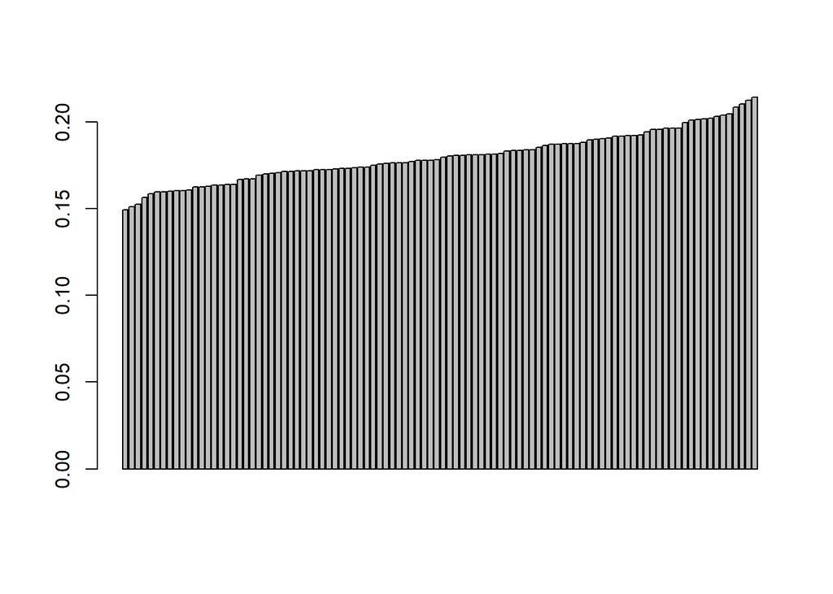

```
##         [,1]
##   [1,]   0.7
##   [2,]   1.9
##   [3,]   3.1
##   [4,]   4.3
##   [5,]   5.5
##   [6,]   6.7
##   [7,]   7.9
##   [8,]   9.1
##   [9,]  10.3
##  [10,]  11.5
##  [11,]  12.7
##  [12,]  13.9
##  [13,]  15.1
##  [14,]  16.3
```

[output cut: 86 more lines]

```r
setkey(cohort,hosp_id)
res1 <-
  cohort[,list(mort_rate=sum(mortality == "Yes")/.N),
         by=hosp_id]
setorder(res1,mort_rate)
res1[,barplot(mort_rate)]
```

# Data.table and the i argument

- When we pass a list or data.table or `J` into the `i` argument, we are technically performing a join which results in subset (like in the previous slides)
- We can specify which of the joined rows are returned with the `mult=` argument
- The options for `mult=` include “all” (the default), “first” and “last”

```r
## sort by hospital id then age
setkey(cohort,hosp_id,age)
## join all the rows in hospitals one to three
cohort[J(c(1,2,3))]
```

```
##       patient_id hosp_id age gender mortality  SES    l_age    age_cat risk_cat avg_age_hosp
##    1:     159292       1  31   Male        No  Med 3.433987      Young      Low     65.08249
##    2:     117968       1  31   Male       Yes  Med 3.433987      Young      Low     65.08249
##    3:     139877       1  34   Male        No  Med 3.526361      Young      Low     65.08249
##    4:     112040       1  36 Female        No  Med 3.583519      Young      Low     65.08249
##    5:     135266       1  36   Male        No  Med 3.583519      Young      Low     65.08249
##   ---
## 2917:     113069       3  92   Male        No  Med 4.521789 Less Young     High     65.24230
## 2918:     190428       3  92   Male        No  Med 4.521789 Less Young     High     65.24230
## 2919:     172256       3  95   Male        No High 4.553877 Less Young     High     65.24230
## 2920:     185063       3  95   Male        No  Med 4.553877 Less Young     High     65.24230
## 2921:     192823       3  95   Male        No High 4.553877 Less Young     High     65.24230
```

```r
## join only to the first row
## youngest person per hospital
cohort[J(c(1,2,3)),mult="first"]
```

```
##    patient_id hosp_id age gender mortality  SES    l_age age_cat risk_cat avg_age_hosp
## 1:     159292       1  31   Male        No  Med 3.433987   Young      Low     65.08249
## 2:     158174       2  33   Male        No  Low 3.496508   Young      Low     65.09864
## 3:     103987       3  34   Male        No High 3.526361   Young      Low     65.24230
```

```r
## join only to the last row
## oldest person per hospital
cohort[J(c(1,2,3)),mult="last"]
```

```
##    patient_id hosp_id age gender mortality  SES    l_age    age_cat risk_cat avg_age_hosp
## 1:     175169       1  98   Male        No  Med 4.584967 Less Young     High     65.08249
## 2:     100971       2 100   Male        No  Low 4.605170 Less Young     High     65.09864
## 3:     192823       3  95   Male        No High 4.553877 Less Young     High     65.24230
```

# Joins in Data.table

- We have already seen an example of a join in data.table when leveraging the keys and using `J` in the `i` argument
- We can join two data.tables together using the `i` argument, and the keys dictate which columns are joined

```r
## read in hospital traits for example joins
hosp <- fread("Data/hosp_demo.csv")
## set keys for both tables (these are the things we will merge on)
setkey(hosp,hosp_id)
setkey(cohort,hosp_id)

## right join: all the hospitals and whatever patients match
cohort[hosp]
```

```
##         patient_id hosp_id age gender mortality SES    l_age    age_cat risk_cat avg_age_hosp academic
##      1:     159292       1  31   Male        No Med 3.433987      Young      Low     65.08249      Yes
##      2:     117968       1  31   Male       Yes Med 3.433987      Young      Low     65.08249      Yes
##      3:     139877       1  34   Male        No Med 3.526361      Young      Low     65.08249      Yes
##      4:     112040       1  36 Female        No Med 3.583519      Young      Low     65.08249      Yes
##      5:     135266       1  36   Male        No Med 3.583519      Young      Low     65.08249      Yes
##     ---
##  99996:     132099     100  89   Male        No Med 4.488636 Less Young     High     64.25282       No
##  99997:     105295     100  90   Male        No Low 4.499810 Less Young     High     64.25282       No
##  99998:     184176     100  91   Male        No Low 4.510860 Less Young     High     64.25282       No
##  99999:     192159     100  94   Male        No Med 4.543295 Less Young     High     64.25282       No
## 100000:     143580     100  98   Male       Yes Low 4.584967 Less Young     High     64.25282       No
```

```r
## left join: all the patients and whatever hospitals match
hosp[cohort]
```

```
##         hosp_id academic patient_id age gender mortality SES    l_age    age_cat risk_cat avg_age_hosp
##      1:       1      Yes     159292  31   Male        No Med 3.433987      Young      Low     65.08249
##      2:       1      Yes     117968  31   Male       Yes Med 3.433987      Young      Low     65.08249
##      3:       1      Yes     139877  34   Male        No Med 3.526361      Young      Low     65.08249
##      4:       1      Yes     112040  36 Female        No Med 3.583519      Young      Low     65.08249
##      5:       1      Yes     135266  36   Male        No Med 3.583519      Young      Low     65.08249
##     ---
##  99996:     100       No     132099  89   Male        No Med 4.488636 Less Young     High     64.25282
##  99997:     100       No     105295  90   Male        No Low 4.499810 Less Young     High     64.25282
##  99998:     100       No     184176  91   Male        No Low 4.510860 Less Young     High     64.25282
##  99999:     100       No     192159  94   Male        No Med 4.543295 Less Young     High     64.25282
## 100000:     100       No     143580  98   Male       Yes Low 4.584967 Less Young     High     64.25282
```

```r
## inner join: only the overlapping hospitals and patients
hosp[cohort,nomatch=0]
```

```
##         hosp_id academic patient_id age gender mortality SES    l_age    age_cat risk_cat avg_age_hosp
##      1:       1      Yes     159292  31   Male        No Med 3.433987      Young      Low     65.08249
##      2:       1      Yes     117968  31   Male       Yes Med 3.433987      Young      Low     65.08249
##      3:       1      Yes     139877  34   Male        No Med 3.526361      Young      Low     65.08249
##      4:       1      Yes     112040  36 Female        No Med 3.583519      Young      Low     65.08249
##      5:       1      Yes     135266  36   Male        No Med 3.583519      Young      Low     65.08249
##     ---
##  99996:     100       No     132099  89   Male        No Med 4.488636 Less Young     High     64.25282
##  99997:     100       No     105295  90   Male        No Low 4.499810 Less Young     High     64.25282
##  99998:     100       No     184176  91   Male        No Low 4.510860 Less Young     High     64.25282
##  99999:     100       No     192159  94   Male        No Med 4.543295 Less Young     High     64.25282
## 100000:     100       No     143580  98   Male       Yes Low 4.584967 Less Young     High     64.25282
```

```r
## Full join (all patients and hospitals, even if they don't match)
merge(hosp,cohort,all=TRUE)
```

```
##         hosp_id academic patient_id age gender mortality SES    l_age    age_cat risk_cat avg_age_hosp
##      1:       1      Yes     159292  31   Male        No Med 3.433987      Young      Low     65.08249
##      2:       1      Yes     117968  31   Male       Yes Med 3.433987      Young      Low     65.08249
##      3:       1      Yes     139877  34   Male        No Med 3.526361      Young      Low     65.08249
##      4:       1      Yes     112040  36 Female        No Med 3.583519      Young      Low     65.08249
##      5:       1      Yes     135266  36   Male        No Med 3.583519      Young      Low     65.08249
##     ---
##  99996:     100       No     132099  89   Male        No Med 4.488636 Less Young     High     64.25282
##  99997:     100       No     105295  90   Male        No Low 4.499810 Less Young     High     64.25282
##  99998:     100       No     184176  91   Male        No Low 4.510860 Less Young     High     64.25282
##  99999:     100       No     192159  94   Male        No Med 4.543295 Less Young     High     64.25282
## 100000:     100       No     143580  98   Male       Yes Low 4.584967 Less Young     High     64.25282
```

# Updating columns in place through a join

- We can efficiently add variables into a table with a modification in place using these joins as well.
- A common code pattern I use is to set the keys, then merge with a lookup in the i= position
- You can then reference the data.table in the i position using `i.xxxxx`. I show an example of this below:

```r
# set the keys
setkey(cohort,hosp_id)
setkey(hosp,hosp_id)
# use i. to update the variable name
cohort[hosp,academic_new:=i.academic]
head(cohort[,list(patient_id,academic_new)])
```

```
##    patient_id academic_new
## 1:     159292          Yes
## 2:     117968          Yes
## 3:     139877          Yes
## 4:     112040          Yes
## 5:     135266          Yes
## 6:     198079          Yes
```

# .SD in Data.table

- Sometimes we may want to touch the entire data.table at once inside of the `J` argument, perhaps while using an lapply or sapply statement
- `.SD` can be used in the `j` argument. It is a subset of the data with all columns excluding the `by=` column
- `.SDcols` can be used to specify which columns will be included in `.SD`

```r
## use mtcars data as an example
data(mtcars)
mtcars_dt <- data.table(mtcars)
mtcars_dt[,lapply(.SD,mean),by=am]
```

```
##    am      mpg      cyl     disp       hp     drat       wt     qsec        vs     gear     carb
## 1:  1 24.39231 5.076923 143.5308 126.8462 4.050000 2.411000 17.36000 0.5384615 4.384615 2.923077
## 2:  0 17.14737 6.947368 290.3789 160.2632 3.286316 3.768895 18.18316 0.3684211 3.210526 2.736842
```

```r
## Pass in a function to return multiple items
mtcars_dt[,lapply(.SD, function(x) c(mean=mean(x),stdev=sd(x)))]
```

```
##          mpg      cyl     disp        hp      drat        wt      qsec        vs        am      gear   carb
## 1: 20.090625 6.187500 230.7219 146.68750 3.5965625 3.2172500 17.848750 0.4375000 0.4062500 3.6875000 2.8125
## 2:  6.026948 1.785922 123.9387  68.56287 0.5346787 0.9784574  1.786943 0.5040161 0.4989909 0.7378041 1.6152
```

```r
mtcars_dt[,lapply(.SD, function(x) c(mean=mean(x),stdev=sd(x))),
          by=am]
```

```
##    am       mpg      cyl      disp        hp      drat        wt      qsec        vs      gear     carb
## 1:  1 24.392308 5.076923 143.53077 126.84615 4.0500000 2.4110000 17.360000 0.5384615 4.3846154 2.923077
## 2:  1  6.166504 1.552500  87.20399  84.06232 0.3640513 0.6169816  1.792359 0.5188745 0.5063697 2.177978
## 3:  0 17.147368 6.947368 290.37895 160.26316 3.2863158 3.7688947 18.183158 0.3684211 3.2105263 2.736842
## 4:  0  3.833966 1.544657 110.17165  53.90820 0.3923039 0.7774001  1.751308 0.4955946 0.4188539 1.147079
```

# .SD in Data.table

- `.SDcols` can be used to specify which columns will be included in `.SD`
- Notice that the names of the object are being stripped when returned. This was not always the case but the current version of data.table does this. One way around it is to unlist, then recreate the list. I am not sure why this happens but this is one current workaround. You could also rename the results accordingly

```r
## only some columns
mtcars_dt[,lapply(.SD,function(x) c(mean=mean(x),stdev=sd(x))),
          by=am,
          .SDcols=c("mpg","cyl","disp")]
```

```
##    am       mpg      cyl      disp
## 1:  1 24.392308 5.076923 143.53077
## 2:  1  6.166504 1.552500  87.20399
## 3:  0 17.147368 6.947368 290.37895
## 4:  0  3.833966 1.544657 110.17165
```

```r
mtcars_dt[,lapply(.SD,function(x) c(mean=mean(x),stdev=sd(x))),
          by=am,
          .SDcols=c(1:3)]
```

```
##    am       mpg      cyl      disp
## 1:  1 24.392308 5.076923 143.53077
## 2:  1  6.166504 1.552500  87.20399
## 3:  0 17.147368 6.947368 290.37895
## 4:  0  3.833966 1.544657 110.17165
```

```r
## retain the names from the function object
## unlist to get names, then force list to get a data.table back
## now it is in wide format though
mtcars_dt[,as.list(unlist(lapply(.SD,function(x) c(mean=mean(x),
                                                      stdev=sd(x))))),
          by=am,
          .SDcols=c(1:3)]
```

```
##    am mpg.mean mpg.stdev cyl.mean cyl.stdev disp.mean disp.stdev
## 1:  1 24.39231  6.166504 5.076923  1.552500  143.5308   87.20399
## 2:  0 17.14737  3.833966 6.947368  1.544657  290.3789  110.17165
```

# Renaming Columns with Data.Table

- We can rename the columns of a data.table with the `setnames()` function
- We can rename a subset of the columns by name, or all of the columns at once
- This syntax is slightly confusing. The first argument is the data.table. If only two arguments are provided, the second argument is the new names. If three arguments are provided, the second argument is the old names and the third argument is the new names.

```r
## set all to upper case
setnames(cohort,toupper(names(cohort)))
## opionally provide the current names, set to lower
setnames(cohort,names(cohort),tolower(names(cohort)))
## only change one name
setnames(cohort,"age","raw_age")
```

# Exercise

```r
# answer here
```

- Answer

```r
res1 <-
  baseball_dt[year > 2000,
              as.list(unlist(lapply(.SD,function(x)
                c("mean"=mean(x),"sd"=sd(x))))),
              by=lg,.SDcols=c("h","r")]
res1
```

```
##    lg   h.mean     h.sd   r.mean     r.sd
## 1: AL 44.74757 55.52511 24.03107 31.55101
## 2: NL 46.53377 56.14662 24.69272 32.28575
```

# Conclusion

- Data.table functionality we covered
- Quickly read in files with `fread`
- Use the square brackets to interact with the data.table
- The first `i` argument subsets the data or joins if a data.table is given
- The second `j` argument accepts any valid r expressions
- If `j` resolves to a simple list a data.table is returned
- We can update or add columns using the `:=` operator
- We can do any of these operations by group using the `by=` command
- Data.table is faster than base R in many tasks
- Data.table uses memory more efficiently by making less copies of datasets as you work with them
- Data.table is one of the fastest ways to merge and work with big data in R